# CAPSTONE PROJECT (Real Estate Case Study)

```python
print(list(density_eda_df.nsmallest(150, 'median_age').state.unique()))
print(len(list(density_eda_df.nsmallest(150, 'median_age').state.unique())))
```

```
['New York', 'Ohio', 'Georgia', 'New Jersey', 'Texas', 'Colorado', 'Virginia', 'California', 'Mississippi', 'Oregon', 'Arizona', 'Utah', 'Pennsylvania', 'Michigan', 'Arkansas', 'Maine', 'Florida', 'North Carolina', 'Minnesota', 'Iowa', 'Connecticut', 'Maryland', 'Wisconsin', 'Louisiana', 'Alabama', …
34
```

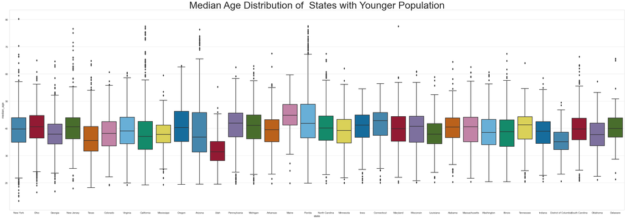

```python
sns.set_style("whitegrid")
plt.figure(figsize = (45, 15))
ax = sns.boxplot(x = 'state', y = 'median_age', data=density_eda_df.nsmallest(26585, 'median_age'), palette=color_pal,
            order = ['New York', 'Ohio', 'Georgia', 'New Jersey', 'Texas', 'Colorado', 'Virginia', 'California', 'Mississippi', 'Oregon', 'Arizona', 'Utah', 'Pennsylvania', 'Michigan', 'Arkansas', 'Maine', 'Florida', 'North Carolina',
                     'Minnesota', 'Iowa', 'Connecticut', 'Maryland', 'Wisconsin', 'Louisiana', 'Alabama', 'Massachusetts', 'Washington', 'Illinois', 'Tennessee', 'Indiana', 'District of Columbia', 'South Carolina', 'Oklahoma', 'Delaware']
           ).set_title('Median Age Distribution of  States with Younger Population', fontsize = 40)
#ax.set(ylim=(0, 100))
plt.show()
```

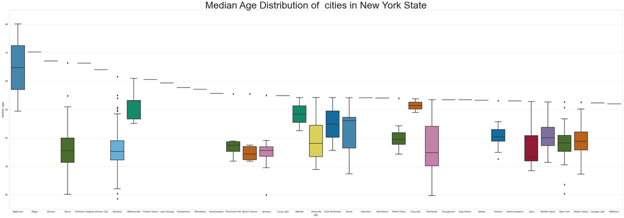

```python
sns.set_style("whitegrid")
plt.figure(figsize = (45, 15))
ax = sns.boxplot(x = 'city', y = 'median_age', data=density_eda_df[density_eda_df['state'] == 'New York'].nlargest(26585, 'median_age'), palette=color_pal,
            order =['Bellerose', 'Ridge', 'Somers', 'Bronx', 'Yorktown Heights', 'Johnson City', 'Brooklyn', 'Williamsville', 'Fishers Island', 'Lake George', 'Chestertown', 'Rhinebeck',
                    'Southampton', 'Richmond Hill', 'Mount Vernon', 'Jamaica', 'Long Lake', 'Melville', 'Amityville', 'East Rochester', 'Rome', 'Calverton', 'Woodstock', 'White Plains', 'Craryville',
                    'Rochester', 'Youngstown', 'Sag Harbor', 'Valatie', 'Yonkers', 'Hammondsport', 'Utica', 'Middle Island', 'New York', 'Staten Island', 'Caroga Lake', 'Willsboro']
)
ax.set_title('Median Age Distribution of  cities in New York State', fontsize = 40)
ax.set(ylim=(15, 85))
plt.show()
```

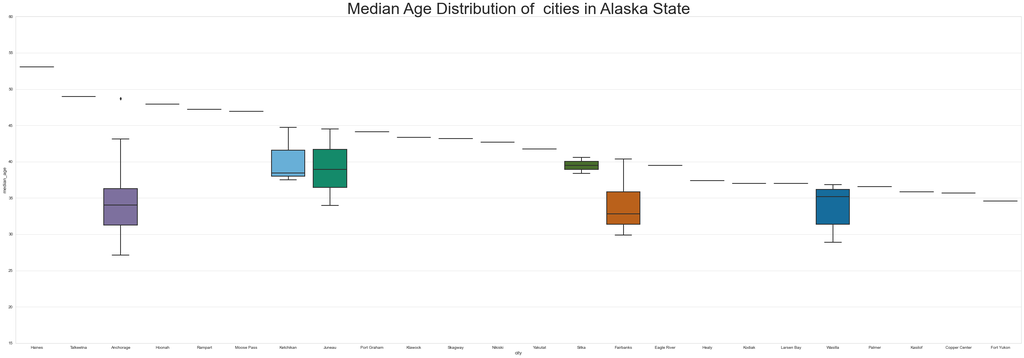

```python
sns.set_style("whitegrid")
plt.figure(figsize = (45, 15))
ax = sns.boxplot(x = 'city', y = 'median_age', data=density_eda_df[density_eda_df['state'] == 'Alaska'].nlargest(26585, 'median_age'), palette=color_pal,
            order =['Haines', 'Talkeetna', 'Anchorage', 'Hoonah', 'Rampart', 'Moose Pass', 'Ketchikan', 'Juneau', 'Port Graham', 'Klawock', 'Skagway', 'Nikiski', 'Yakutat', 'Sitka', 'Fairbanks',
                    'Eagle River', 'Healy', 'Kodiak', 'Larsen Bay', 'Wasilla', 'Palmer', 'Kasilof', 'Copper Center', 'Fort Yukon']
)
ax.set_title('Median Age Distribution of  cities in Alaska State', fontsize = 40)
ax.set(ylim=(15, 60))
plt.show()
```

```python
list(density_eda_df[density_eda_df['state'] == 'New York'].nlargest(600, 'pop_density').place.unique())
print(len(list(density_eda_df[density_eda_df['state'] == 'New York'].nlargest(600, 'pop_density').place.unique())))
```

```
19
```

```python
print(list(density_eda_df[density_eda_df['state'] == 'Alaska'].nlargest(42, 'median_age').city.unique()))
print(len(list(density_eda_df[density_eda_df['state'] == 'Alaska'].nlargest(42, 'median_age').city.unique())))
```

```
['Haines', 'Talkeetna', 'Anchorage', 'Hoonah', 'Rampart', 'Moose Pass', 'Ketchikan', 'Juneau', 'Port Graham', 'Klawock', 'Skagway', 'Nikiski', 'Yakutat', 'Sitka', 'Fairbanks', 'Eagle River', 'Healy', 'Kodiak', 'Larsen Bay', 'Wasilla', 'Palmer', 'Kasilof', 'Copper Center', 'Fort Yukon']
24
```

```python
train_df.head()
```

|  | UID | SUMLEVEL | COUNTYID | STATEID | state | state_ab | city | place | type | zip_code | area_code | lat | lng | ALand | AWater | pop | male_pop | female_pop | rent_mean | rent_median | rent_stdev | rent_sample_weight | rent_samples | rent_gt_10 | rent_gt_15 | rent_gt_20 | rent_gt_25 | rent_gt_30 | rent_gt_35 | … |
| --- | --- | --- | --- | --- | --- | --- | --- | --- | --- | --- | --- | --- | --- | --- | --- | --- | --- | --- | --- | --- | --- | --- | --- | --- | --- | --- | --- | --- | --- | --- |
| 0 | 267822 | 140 | 53 | 36 | New York | NY | Hamilton | Hamilton | City | 13346 | 315 | 42.840812 | -75.501524 | 202183361.0 | 1699120 | 5230 | 2612 | 2618 | 769.38638 | 784.0 | 232.63967 | 272.34441 | 362.0 | 0.86761 | 0.79155 | 0.59155 | 0.45634 | 0.42817 | 0.18592 | … |
| 1 | 246444 | 140 | 141 | 18 | Indiana | IN | South Bend | Roseland | City | 46616 | 574 | 41.701441 | -86.266614 | 1560828.0 | 100363 | 2633 | 1349 | 1284 | 804.87924 | 848.0 | 253.46747 | 312.58622 | 513.0 | 0.97410 | 0.93227 | 0.69920 | 0.69920 | 0.55179 | 0.41235 | … |
| 2 | 245683 | 140 | 63 | 18 | Indiana | IN | Danville | Danville | City | 46122 | 317 | 39.792202 | -86.515246 | 69561595.0 | 284193 | 6881 | 3643 | 3238 | 742.77365 | 703.0 | 323.39011 | 291.85520 | 378.0 | 0.95238 | 0.88624 | 0.79630 | 0.66667 | 0.39153 | 0.39153 | … |
| 3 | 279653 | 140 | 127 | 72 | Puerto Rico | PR | San Juan | Guaynabo | Urban | 927 | 787 | 18.396103 | -66.104169 | 1105793.0 | 0 | 2700 | 1141 | 1559 | 803.42018 | 782.0 | 297.39258 | 259.30316 | 368.0 | 0.94693 | 0.87151 | 0.69832 | 0.61732 | 0.51397 | 0.46927 | … |
| 4 | 247218 | 140 | 161 | 20 | Kansas | KS | Manhattan | Manhattan City | City | 66502 | 785 | 39.195573 | -96.569366 | 2554403.0 | 0 | 5637 | 2586 | 3051 | 938.56493 | 881.0 | 392.44096 | 1005.42886 | 1704.0 | 0.99286 | 0.98247 | 0.91688 | 0.84740 | 0.78247 | 0.60974 | … |

# 2. Create bins for population into a new variable by selecting appropriate class interval so that the number of categories don’t exceed 5 for the ease of analysis. a) Analyze the married, separated, and divorced population for these population brackets b) Visualize using appropriate chart type.

```python
age_df = train_df[['state', 'city', 'place', 'pop', 'male_pop', 'female_pop', 'male_age_median', 'female_age_median', 'married', 'separated', 'divorced']]
```

```python
train_df.male_age_median.unique()
```

[output not shown]

[output cut: 58 more lines]

[output not shown]

The IntelliSense Age Group defaults are:

Youth (<18)

Young Adult (18 to 35)

Adult (36 to 55)

Senior (56 and up)

```python
bins = [0, 12,18, 35, 55, 100]
labels = ['kids', 'Youth', 'Young Adult', 'Adult', 'Senior']
#df['binned'] = pd.cut(df['percentage'], bins, labels = labels)
```

```python
age_df['male_population_bracket'] = pd.cut(age_df['male_age_median'], bins, labels = labels)
```

```python
age_df['female_population_bracket'] = pd.cut(age_df['female_age_median'], bins, labels = labels)
```

```python
age_df.head()
```

|  | state | city | place | pop | male_pop | female_pop | male_age_median | female_age_median | married | separated | divorced | male_population_bracket | female_population_bracket |
| --- | --- | --- | --- | --- | --- | --- | --- | --- | --- | --- | --- | --- | --- |
| 0 | New York | Hamilton | Hamilton | 5230 | 2612 | 2618 | 44.00000 | 45.33333 | 0.57851 | 0.01240 | 0.08770 | Adult | Adult |
| 1 | Indiana | South Bend | Roseland | 2633 | 1349 | 1284 | 32.00000 | 37.58333 | 0.34886 | 0.01426 | 0.09030 | Young Adult | Adult |
| 2 | Indiana | Danville | Danville | 6881 | 3643 | 3238 | 40.83333 | 42.83333 | 0.64745 | 0.01607 | 0.10657 | Adult | Adult |
| 3 | Puerto Rico | San Juan | Guaynabo | 2700 | 1141 | 1559 | 48.91667 | 50.58333 | 0.47257 | 0.02021 | 0.10106 | Adult | Adult |
| 4 | Kansas | Manhattan | Manhattan City | 5637 | 2586 | 3051 | 22.41667 | 21.58333 | 0.12356 | 0.00000 | 0.03109 | Young Adult | Young Adult |

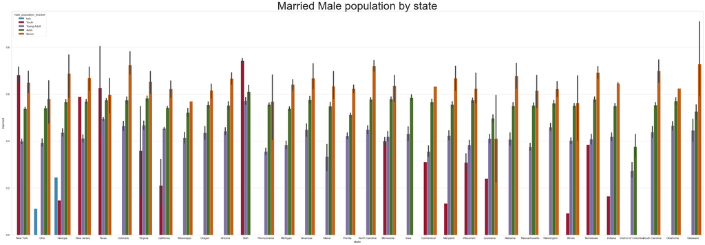

```python
sns.set_style("whitegrid")

plt.figure(figsize = (45, 15))

ax = sns.barplot(x = 'state', y = 'married', hue = 'male_population_bracket', data = age_df, palette=color_pal,
           order = ['New York', 'Ohio', 'Georgia', 'New Jersey', 'Texas', 'Colorado', 'Virginia', 'California', 'Mississippi', 'Oregon', 'Arizona', 'Utah', 'Pennsylvania', 'Michigan', 'Arkansas', 'Maine', 'Florida', 'North Carolina',
                     'Minnesota', 'Iowa', 'Connecticut', 'Maryland', 'Wisconsin', 'Louisiana', 'Alabama', 'Massachusetts', 'Washington', 'Illinois', 'Tennessee', 'Indiana', 'District of Columbia', 'South Carolina', 'Oklahoma', 'Delaware'])

ax.set_title('Married Male population by state', fontsize = 40)

plt.show()
```